# Trp53cor1 KO vs WT (Liver)

# Gene/Pathway Analysis

## GSEA

Enrichment and zscores are calculated based on expression in KO vs WT (fpkmKO/fpkmWT), so genes that are down regulated in KO are shown in blue, while upregulation is shown in red.

KO/WT Blue = down in KO Red = Up in KO

Biocarta enrichment:

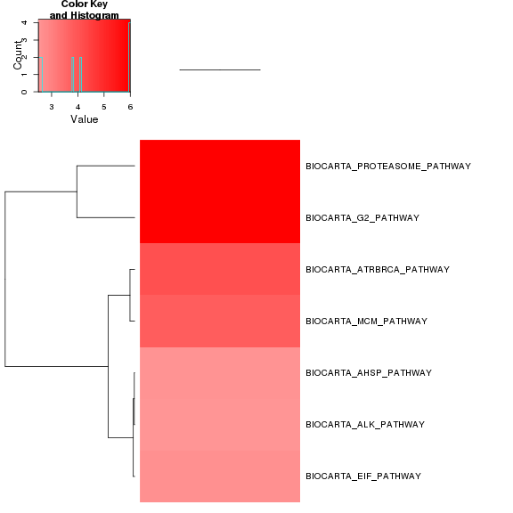

Biocarta zscore:

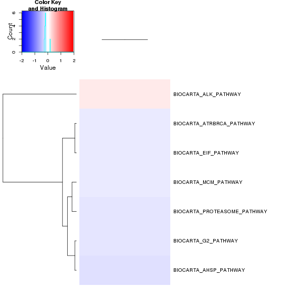

Reactome enrichment:

```
## Error in (function (side, at = NULL, labels = TRUE, tick = TRUE, line = NA, : no locations are finite
```

[figure not shown]

Reactome zscore:

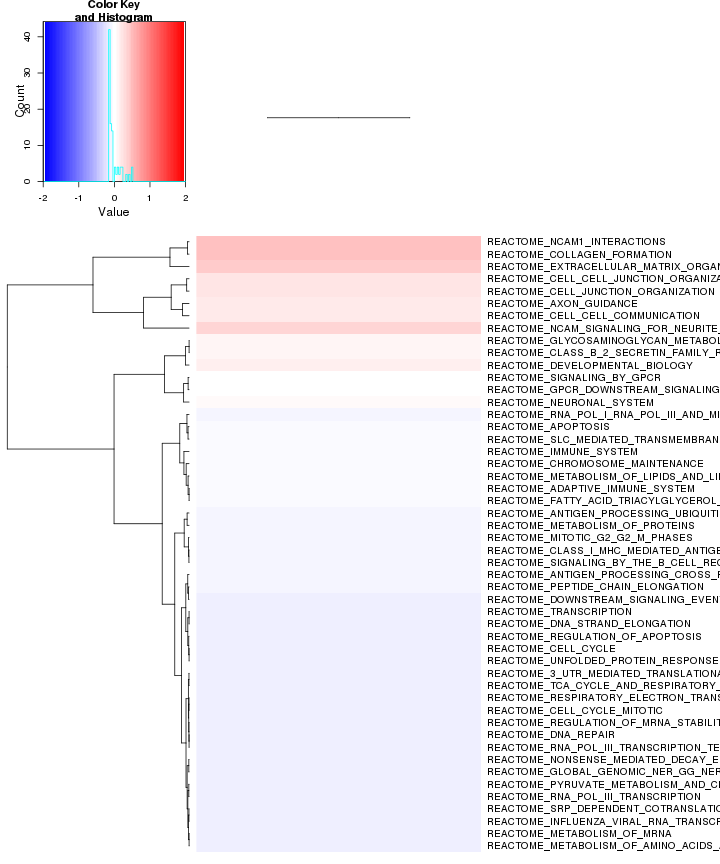

Kegg enrichment:

```
## Error in x_ordered[1:50, ]: subscript out of bounds
```

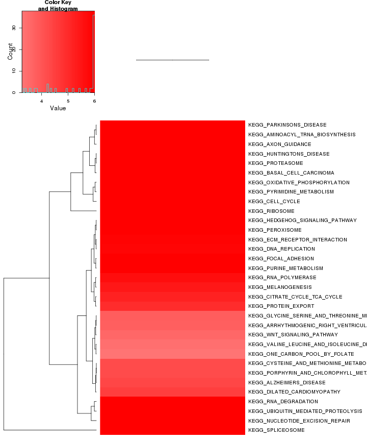

Kegg zscore:

```
## Error in x_ordered[1:50, ]: subscript out of bounds
```

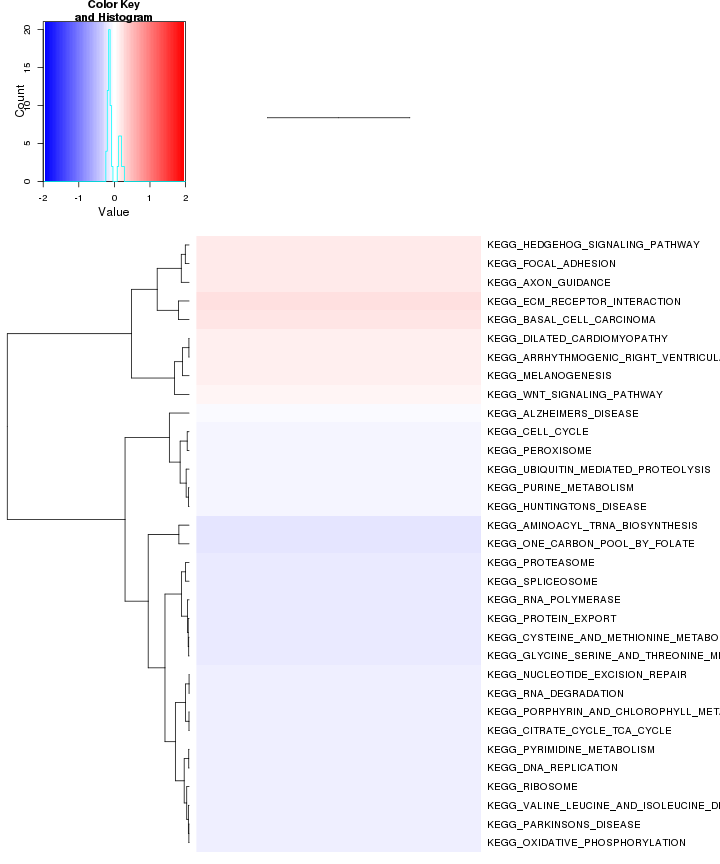

p53 enrichment:

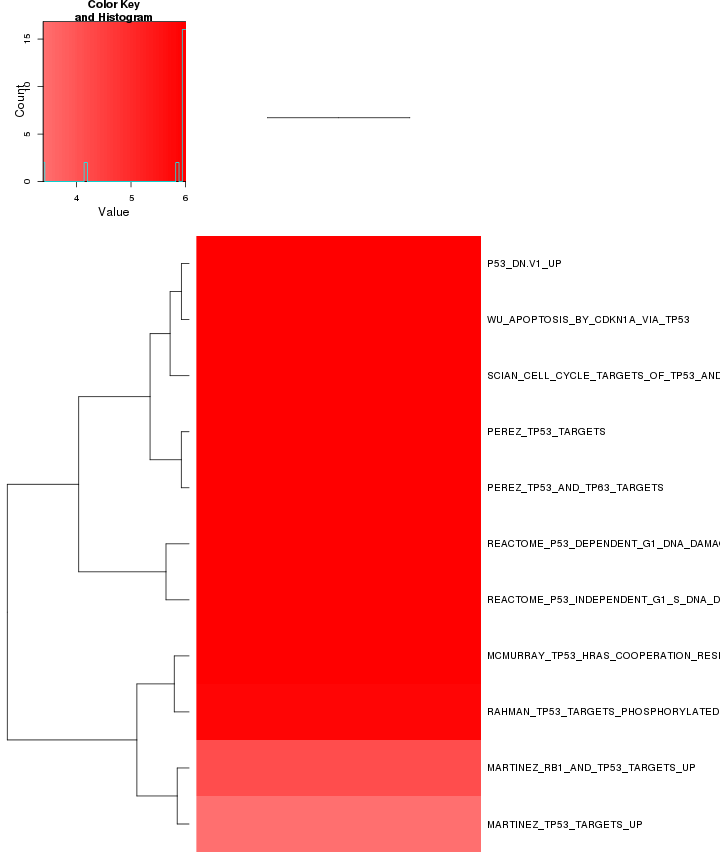

p53 zscore:

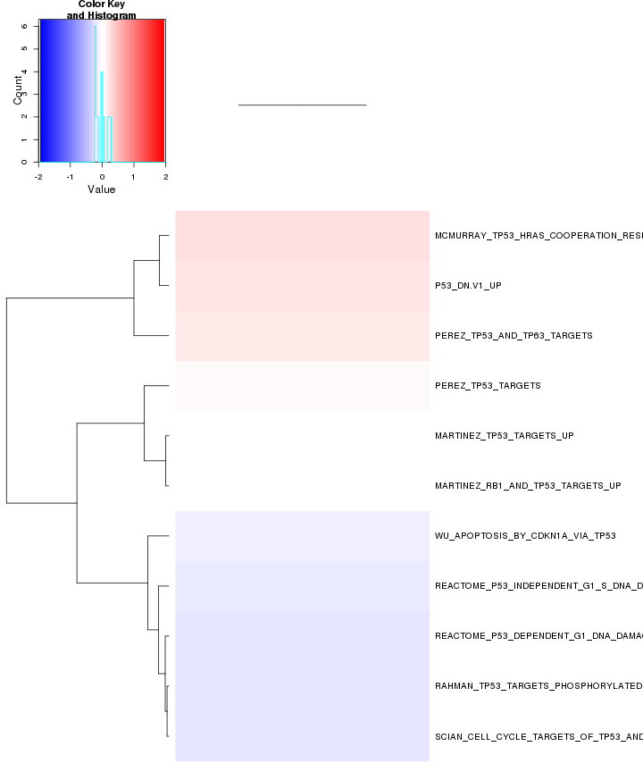

Oncogene enrichment:

```
## Error in x_ordered[1:50, ]: subscript out of bounds
```

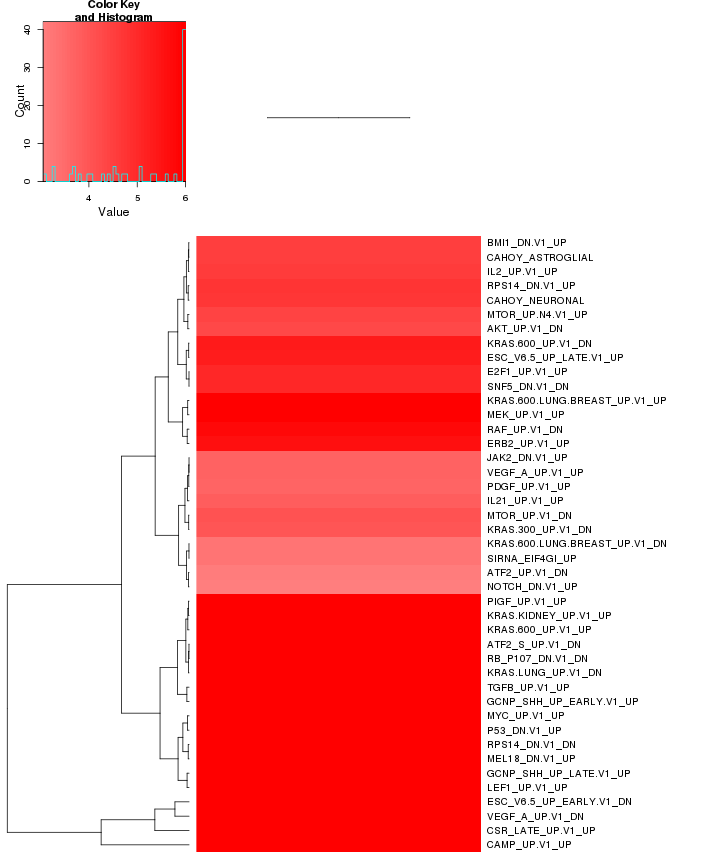

Oncogene zscore:

```
## Error in x_ordered[1:50, ]: subscript out of bounds
```

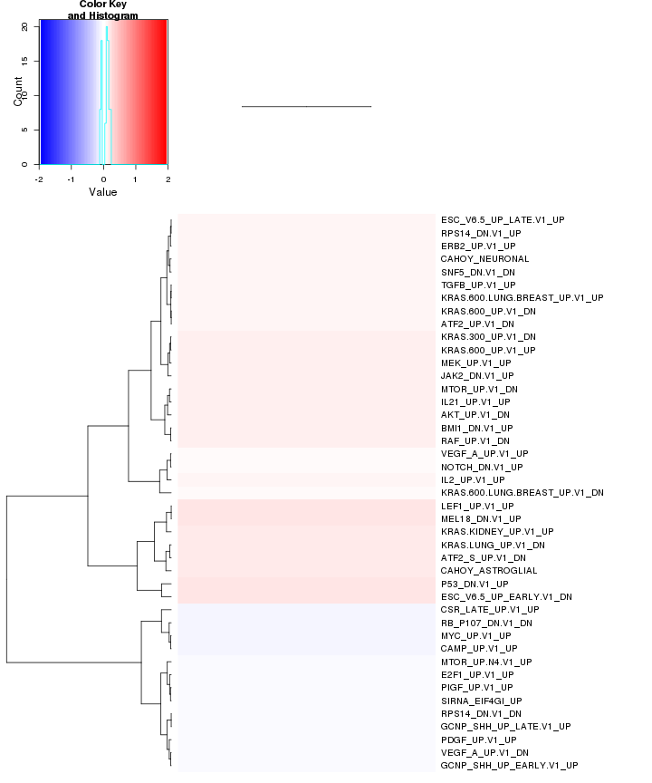

Jacks enrichment

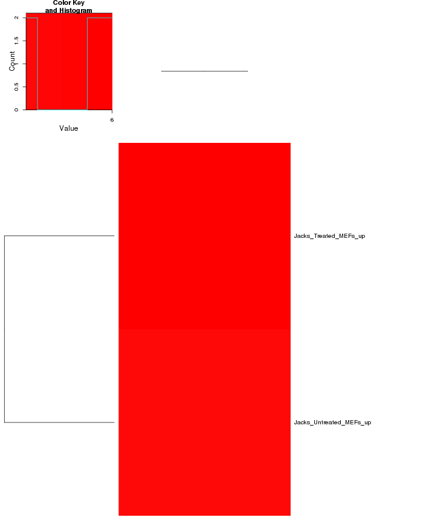

Jacks zscore

[figure not shown]

All enrichment

There are 2786 categories enriched (p<0.0001). They are:

```
## Error in (function (side, at = NULL, labels = TRUE, tick = TRUE, line = NA, : no locations are finite
```

[figure not shown]

ALL zscore:

[figure not shown]

## GO enrichment

Cluster profiler used to call enichments of significantly differentially regulated genes that map to Entrez IDs.

```
## [1] "ERROR: The estimated pi0 <= 0. Check that you have valid p-values or use another lambda method."
```

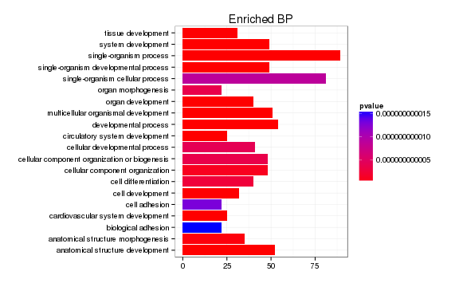

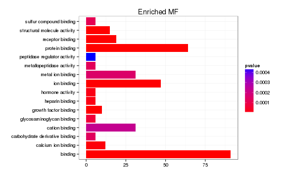

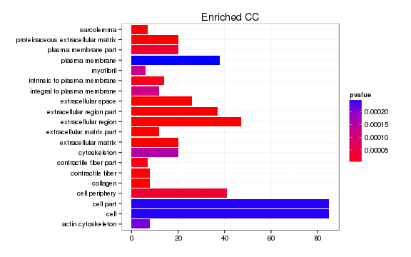

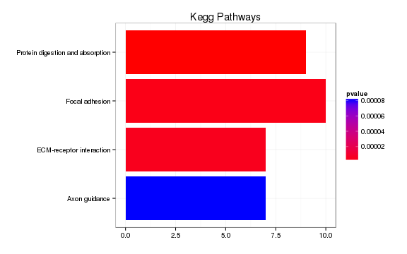

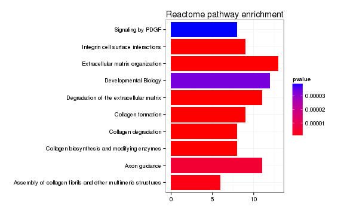

# Cis vs Trans (locally)

log2 Foldchange and test statistic are calculated with the ratio of fpkm(KO)/fpkm(WT), thus the test_stat is positive if a gene is higher in the KO and negative if a gene has lower expression in the KO

The pvalue for genes significantly regulated in a region this size is: 0.0132

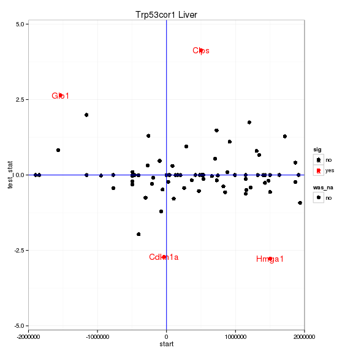

# Notes

## Samples used are:

|  | 11 |
| --- | --- |
| 1 | JR917 |
| 2 | JR933 |
| 3 | JR925 |
| 4 | JR926 |
| 5 | JR934 |

## Replicates

|  | file | sample_name | replicate | rep_name | total_mass | norm_mass | internal_scale | external_scale |
| --- | --- | --- | --- | --- | --- | --- | --- | --- |
| 1 | /n/rinn_data1/users/agroff/seq/OtherMice/Diana/lincP21/quants/JR917/abundances.cxb | WT | 0 | WT_0 | 37248000.00 | 36429300.00 | 1.03 | 1.00 |
| 2 | /n/rinn_data1/users/agroff/seq/OtherMice/Diana/lincP21/quants/JR933/abundances.cxb | WT | 1 | WT_1 | 34229100.00 | 36429300.00 | 0.91 | 1.00 |
| 3 | /n/rinn_data1/users/agroff/seq/OtherMice/Diana/lincP21/quants/JR925/abundances.cxb | WT | 2 | WT_2 | 40066200.00 | 36429300.00 | 1.05 | 1.00 |
| 4 | /n/rinn_data1/users/agroff/seq/OtherMice/Diana/lincP21/quants/JR926/abundances.cxb | Trp53cor1 | 0 | Trp53cor1_0 | 40299500.00 | 36429300.00 | 1.17 | 1.00 |
| 5 | /n/rinn_data1/users/agroff/seq/OtherMice/Diana/lincP21/quants/JR934/abundances.cxb | Trp53cor1 | 1 | Trp53cor1_1 | 30681900.00 | 36429300.00 | 0.86 | 1.00 |

## Run Info

[output not shown]